# Day 3

# Exploratory data analysis

**Learning Objectives**

- Why data Visualization?
- Practice using different types of plots.
- Use R methods for plotting.
- Create line plots, bar plots, histograms, and box plots.
- Introduction to ggplot2

[figure not shown]

### **Let’s review the data science lifecycle**

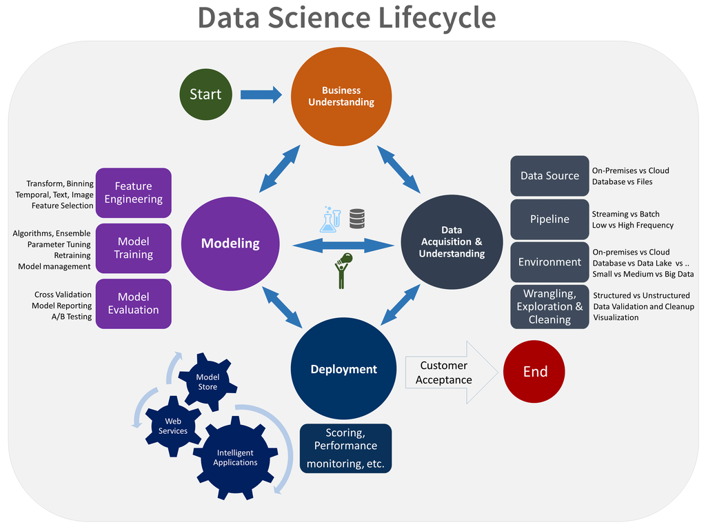

**Data Science is an iterative process**

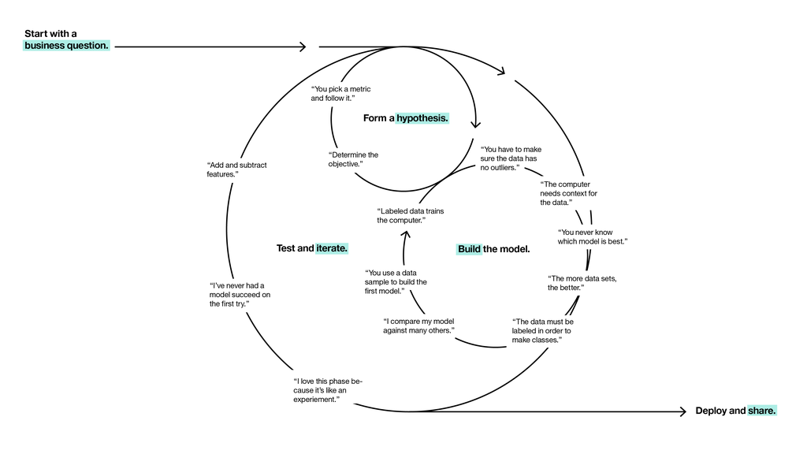

[figure not shown]

### Why Use Data Visualization?

Because of the way the human brain processes information, charts or graphs that visualize large amounts of complex data are easier to understand than spreadsheets or reports.

Data visualization is a quick, easy way to convey concepts in a universal manner — and you can experiment with different scenarios by making slight adjustments.

### **Choosing the right type of visualization**

The choice of visualization should depend what you are trying to show. Here is a helpful flowchart that you can use to determine the best type of visualizations.

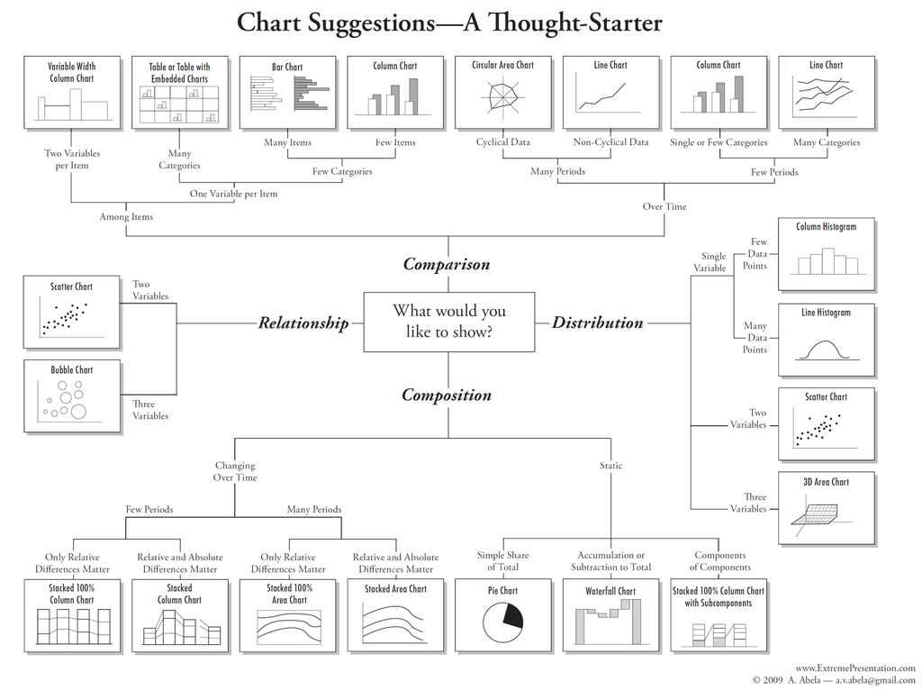

### **The Importance of visualization**

- Given the same data, different visualization styles can convey different messages
- Examples here:
  - https://medium.economist.com/mistakes-weve-drawn-a-few-8cdd8a42d368

[figure not shown]

# **Load in data sets for visualization examples.**

The Boston data dictionary can be found [here](https://archive.ics.uci.edu/ml/machine-learning-databases/housing/housing.names).

```r
# Read in the Boston housing data.
housing_csv = 'data/boston_housing_data.csv'
housing = read.csv(housing_csv)

# Read in the drinks data.
drink_cols = c('country', 'beer', 'spirit', 'wine', 'liters', 'continent')
url = 'data/drinks.csv'
drinks = read.csv(url, header=TRUE, col.names=drink_cols)

# Read in the ufo data.
ufo = read.csv('data/ufo.csv')
head(ufo)
```

```
##                   City Colors.Reported Shape.Reported State            Time
## 1               Ithaca                       TRIANGLE    NY  6/1/1930 22:00
## 2          Willingboro                          OTHER    NJ 6/30/1930 20:00
## 3              Holyoke                           OVAL    CO 2/15/1931 14:00
## 4              Abilene                           DISK    KS  6/1/1931 13:00
## 5 New York Worlds Fair                          LIGHT    NY 4/18/1933 19:00
## 6          Valley City                           DISK    ND 9/15/1934 15:30
```

Let’s work with the date feature:

```r
#create Year attribute
library(lubridate)
ufo$Time = as.Date(ufo$Time,format='%m/%d/%Y')
ufo$Year = year(ufo$Time)
```

### **Understand each dataset well before we try to visualize the data**

```r
head(housing)
```

```
##      CRIM ZN INDUS CHAS   NOX    RM  AGE    DIS RAD TAX PTRATIO      B LSTAT MEDV
## 1 0.00632 18  2.31    0 0.538 6.575 65.2 4.0900   1 296    15.3 396.90  4.98 24.0
## 2 0.02731  0  7.07    0 0.469 6.421 78.9 4.9671   2 242    17.8 396.90  9.14 21.6
## 3 0.02729  0  7.07    0 0.469 7.185 61.1 4.9671   2 242    17.8 392.83  4.03 34.7
## 4 0.03237  0  2.18    0 0.458 6.998 45.8 6.0622   3 222    18.7 394.63  2.94 33.4
## 5 0.06905  0  2.18    0 0.458 7.147 54.2 6.0622   3 222    18.7 396.90  5.33 36.2
## 6 0.02985  0  2.18    0 0.458 6.430 58.7 6.0622   3 222    18.7 394.12  5.21 28.7
```

```r
head(drinks)
```

```
##             country beer spirit wine liters continent
## 1       Afghanistan    0      0    0    0.0        AS
## 2           Albania   89    132   54    4.9        EU
## 3           Algeria   25      0   14    0.7        AF
## 4           Andorra  245    138  312   12.4        EU
## 5            Angola  217     57   45    5.9        AF
## 6 Antigua & Barbuda  102    128   45    4.9      <NA>
```

```r
head(ufo)
```

```
##                   City Colors.Reported Shape.Reported State       Time Year
## 1               Ithaca                       TRIANGLE    NY 1930-06-01 1930
## 2          Willingboro                          OTHER    NJ 1930-06-30 1930
## 3              Holyoke                           OVAL    CO 1931-02-15 1931
## 4              Abilene                           DISK    KS 1931-06-01 1931
## 5 New York Worlds Fair                          LIGHT    NY 1933-04-18 1933
## 6          Valley City                           DISK    ND 1934-09-15 1934
```